# Iris Data Set

## Introduction

The Iris data set problem is a supervised classification task wherein three species of Iris (Iris setosa, Iris virginica and Iris versicolor) must be distinguished using data from four continuous features: sepal width, sepal height, petal width, and petal height. Based on the combination of these four features, Ronald Fisher developed a linear discriminant model to distinguish the species from each other.

## Linear Discriminant Analysis

Linear discriminant analysis (LDA) involves finding a linear combination of continuous features that maximise the seperation between known categories. The result is a projection from the original feature space to a linear subspace consisting of the directions which maximize the separation between classes. A similar classifier is quadratic discriminant analysis (QDA) which learns quadratic boundaries and is better able to model more complex distributions of data. LDA also appears to be similar to Principal Component Analysis (PCA) which reduces the dimensionality of the feature space based on the distribution of data; however, PCA accounts for the variation of all data whereas LDA accounts for the variation between categories and hence is better suited for classifying categorical data.

LDA works via two rules:

1. maximise the distance between the means of each category; and
2. minimise the variation/scatter within each category.

To achieve this, LDA makes the following assumptions:

1. that your data is Gaussian, that each variable is is shaped like a bell curve when plotted; and
2. that each attribute has the same variance, that values of each variable vary around the mean by the same amount on average.

## Applying LDA to the Iris Data Set Problem

For the Iris data set, a linear discriminant model would reduce the four feature dimensions representing sepal/petal width and height such that the distance between the means of each species is maximised and the variation of each species is minimised.

### Data Summary and Visualisation

Let's load the Iris data set from sklearn.

```python
# Load Iris data set
from sklearn import datasets
iris = datasets.load_iris()

# Load pandas
import pandas as pd

# Separate features from labels into dataframes
x = pd.DataFrame(data=iris.data,
                 columns=['sepal_length',
                         'sepal_width',
                         'petal_length',
                         'petal_width'])

y = pd.DataFrame(data=iris.target,
                 columns=['label'])
```

Next we'll look at a statistical summary of the data.

```python
# Get the shape of the data
print(x.shape)
```

```
(150, 4)
```

```python
# Get the shape of the target
print(y.shape)
```

```
(150, 1)
```

```python
# Print the first 10 entries
print(x.head(10))
```

```
   sepal_length  sepal_width  petal_length  petal_width
0           5.1          3.5           1.4          0.2
1           4.9          3.0           1.4          0.2
2           4.7          3.2           1.3          0.2
3           4.6          3.1           1.5          0.2
4           5.0          3.6           1.4          0.2
5           5.4          3.9           1.7          0.4
6           4.6          3.4           1.4          0.3
7           5.0          3.4           1.5          0.2
8           4.4          2.9           1.4          0.2
9           4.9          3.1           1.5          0.1
```

```python
# Describe the data distribution
print(x.describe())
```

```
       sepal_length  sepal_width  petal_length  petal_width
count    150.000000   150.000000    150.000000   150.000000
mean       5.843333     3.057333      3.758000     1.199333
std        0.828066     0.435866      1.765298     0.762238
min        4.300000     2.000000      1.000000     0.100000
25%        5.100000     2.800000      1.600000     0.300000
50%        5.800000     3.000000      4.350000     1.300000
75%        6.400000     3.300000      5.100000     1.800000
max        7.900000     4.400000      6.900000     2.500000
```

```python
# Print the category names
print(iris.target_names)
```

```
['setosa' 'versicolor' 'virginica']
```

```python
# Describe the target distribution
print(y.groupby('label').size())
```

```
label
0    50
1    50
2    50
dtype: int64
```

From this we can see that the data has four features per instance representing the sepal length, sepal width, petal length, and petal height, all of which are numerical values ranging between 0.1 and 7.9. The target data represents the ground truth value for each instance which is either 0, 1, or 2 (representing setoas, versicolor, and virginica respectively). Of the 150 samples there is an equal proportion of each class in the set.

Finally we'll create at a visual representation of the data.

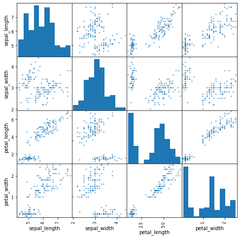

```python
# Load matplotlib
import matplotlib.pyplot as plt

# Load scatter matrix method
from pandas.plotting import scatter_matrix

# Plot multivariate matrix of scatterplots
scatter_matrix(x, figsize=(8,8))
plt.show()
```

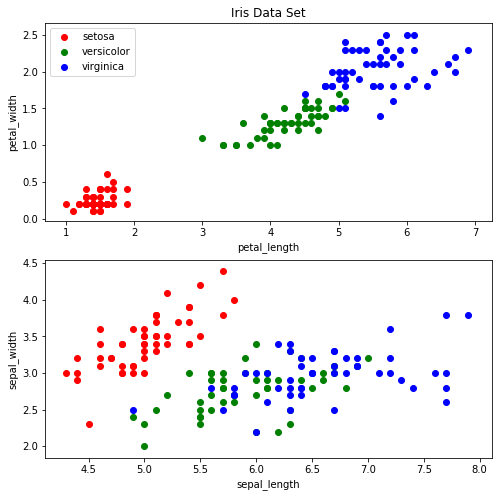

```python
# Load matplotlib
import matplotlib.pyplot as plt

# Create a figure and axis
fig, (ax1, ax2) = plt.subplots(2, 1, figsize=(8,8))
color_list = ['r', 'g', 'b']

# Plot each data point for sepal attributes
for i in range(len(x)):
    ax1.scatter(x['petal_length'][i],
                x['petal_width'][i],
                color=color_list[y['label'][i]])

    ax2.scatter(x['sepal_length'][i],
                x['sepal_width'][i],
                color=color_list[y['label'][i]])


# Set title and labels of plot
ax1.set_title('Iris Data Set')
ax1.set_xlabel('petal_length')
ax1.set_ylabel('petal_width')
ax2.set_xlabel('sepal_length')
ax2.set_ylabel('sepal_width')
ax1.legend(iris.target_names, loc="upper left")
ax1.get_legend().legendHandles[1].set_color('green')
ax1.get_legend().legendHandles[2].set_color('blue')
```

The first diagram is a collage of multivariate plots that demonstrate how each variable interacts with one another allowing us to identify where diagonal grouping appears which may suggest possible correlations or relationships.

We observe that the Petal length and Sepal length scatter plots appear to contain more structure in general, and in particular the Petal width by Petal length plot which exhibits a high degree of diagonal grouping. This has been further demonstrated in the second diagram which is enlarged and illustrates which class each instance belongs to.

Returning to the first diagram we can discern a possible Gaussian distribution from the Sepal length and Sepal width histograms, which is an assumption required for LDA.

### Model Creation and Evaluation

Next we will split the data into a training and testing set.

```python
# Load train_test_split method
from sklearn.model_selection import train_test_split

# Split into training and testing sets
X_train, X_test, Y_train, Y_test = train_test_split(iris.data,
                                                    iris.target,
                                                    test_size=0.20)
```

As mentioned earlier, Fisher was able to construct a linear discriminant model to distinguish the species from one another.

We will train and test the following models:

1. Linear Discriminant Analysis
2. Quadratic Discriminant Analysis

```python
# Load ML models
from sklearn.discriminant_analysis import LinearDiscriminantAnalysis as LDA
from sklearn.discriminant_analysis import QuadraticDiscriminantAnalysis as QDA

# Initialise the models
models = {
    'LDA Model': LDA(),
    'QDA Model': QDA()
}
```

```python
# Train the models
for name in models:
    models[name].fit(X_train, Y_train)
```

```python
# Get model predictions
predictions = {}
for name in models:
    predictions[name] = models[name].predict(X_test)
```

Finally it's time to evaluate the models.

```python
# Load evaluation methods
from sklearn.metrics import accuracy_score
from sklearn.metrics import confusion_matrix
from sklearn.metrics import classification_report

# Evalute model predictions
for name in predictions:
    print("----------------------", name, "----------------------")
    print("Accuracy:", round(accuracy_score(Y_test, predictions[name]), 3))
    print("\nConfusion Matrix: \n", confusion_matrix(Y_test, predictions[name]))
    print("\nClassification Report: \n", classification_report(Y_test, predictions[name]))
```

```
---------------------- LDA Model ----------------------
Accuracy: 0.967

Confusion Matrix:
 [[11  0  0]
 [ 0  8  1]
 [ 0  0 10]]

Classification Report:
               precision    recall  f1-score   support

           0       1.00      1.00      1.00        11
           1       1.00      0.89      0.94         9
           2       0.91      1.00      0.95        10

    accuracy                           0.97        30
   macro avg       0.97      0.96      0.96        30
weighted avg       0.97      0.97      0.97        30

---------------------- QDA Model ----------------------
Accuracy: 0.967

Confusion Matrix:
 [[11  0  0]
 [ 0  8  1]
 [ 0  0 10]]

Classification Report:
               precision    recall  f1-score   support

           0       1.00      1.00      1.00        11
           1       1.00      0.89      0.94         9
           2       0.91      1.00      0.95        10

    accuracy                           0.97        30
   macro avg       0.97      0.96      0.96        30
weighted avg       0.97      0.97      0.97        30
```

When repeated, the results vary slightly depending on the random state of the 'train_test_split' method which divides the samples between the training and testing set. Despite this, we consistently observe an accuracy rating above 96% for both the LDA and QDA model. Taking a closer look at the classification report, we find that the '1' and '2' class (representing the Versicolor and Virginica species) have a lower precision and recall in comparison to class '0' (representing Setosa), which may be because the characteristics of Versicolor and Virginica are more similar and hence more difficult to dissimilate.

### Conclusion

The results of this analysis confirm Fisher's idea that a linear discriminant model is sufficient for the categorisation of the three species of Iris to a high degree of accuracy. The Versicolor and Virginica class are more likely to be misclassified as each other due to their similarity in characteristics, whereas the Setosa class is more dinstinct and hence less likely to be mistaken for another species.